# ti

> **参考文献**

> ```json
> @inproceedings{ganin2015unsupervised,
>   title={Unsupervised domain adaptation by backpropagation},
>   author={Ganin, Yaroslav and Lempitsky, Victor},
>   booktitle={International conference on machine learning},
>   pages={1180--1189},
>   year={2015},
>   organization={PMLR}
> }
> ```

### 文章背景：域适应

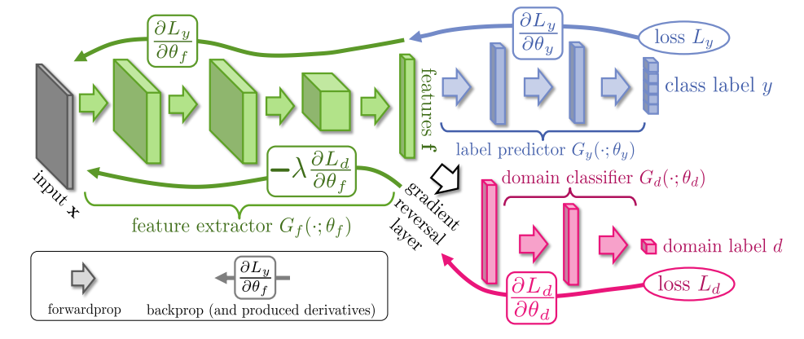

### **文章思路简述**

- 因为原文的目的是域适应，简单来说，就是将一个在源域上训练好的模型迁移到目标域时，要求模型在目标域也要极可能有更好的表现。其本质就是在两种不同但类似的分布的数据集之间寻找一种“迁移”。
- 正向传播时：
  - 蓝色部分：label predictor Gy 用来预测样本的标签。通过min *L*<sub>*y*</sub> 提高其预测能力，因为原文中做的是手写数字识别，故这里是一个分类器，在其他任务中也可以是回归预测器。
  - 红色部分：domain classifier Gd 是一个二分类器，用来预测样本来自源域还是目标域。通过min *L*<sub>*d*</sub>提高其对源域和目标域的分类能力。
  - 绿色部分：是一个Encoder，通过输入数据x提取特征f。
- 反向传播时：
  - 绿色和蓝色的组合，与传统分类任务一样，正常反向传播其梯度。
  - 绿色和红丝的组合，在反向传播过程中增加了一个梯度逆转，该层直接在原有梯度前增加一个 − *λ* 以此实现在优化过程中最大化二分类误差*L*<sub>*d*</sub>，目的是使得Encoder得到的feature尽可能让源域与目标域之间区分不开，也就实现了原文中提到的domain adaptation/domain invariance域自适应。

总的来说，整个网络模型在梯度逆转层的作用下，使得feature extractor在提取特征时能更好地提取到源域和目标域共有的特征，使得网络在目标域上依然保持优秀的的预测能力。

### **手写字识别的应用**

为了验证梯度逆转的实际效果，作者在手写字分类中尝试应用了梯度逆转。

- 首先设置了一个特殊的任务场景，将MINIST数据集分为两类，其一是所有的数字0样本，其二是其他样本。然后以随机的方式，设置两种样本，一种是由数字0样本和其他样本合并而成，另一种是由两个其他样本合并而成。对于含有数字0的样本，标签为1，不含数字0的样本，标签为0。

  ```python
  def gen_new(x):
      other_set = []
      target_set = []
      target = 0
      for i in tqdm(range(len(x_train))):
          if y_train[i] != target:
              other_set.append(x_train[i])
          elif y_train[i] == target:
              target_set.append(x_train[i])
      print(len(target_set))
      randList = np.random.randint(0,2,len(target_set[:4000]))
      new_data = []
      j = 0
      for i in tqdm(randList):
          if i == 1:
              new_data.append(other_set[j] + target_set[j])
          elif i == 0:
              new_data.append(other_set[j] + other_set[j+1])
          j+=1
      new_data = new_data
      label1 = []
      for i in randList:
          if i == 0:
              label1.append(torch.tensor(0))
          elif i == 1:
              label1.append(torch.tensor(1))
      label0 = []
      for i in randList:
          if i == 0:
              label0.append(torch.tensor(1))
          elif i == 1:
              label0.append(torch.tensor(0))
      return new_data,label1,label0
  ```

- 之后设计了一个简单的网络模型，包括梯度逆转层的实现

  ```python
  class GradientReverseFunction(Function):
      """
      重写自定义的梯度计算方式
      """
      @staticmethod
      def forward(ctx: Any, input: torch.Tensor, coeff: Optional[float] = 1.) -> torch.Tensor:
          ctx.coeff = coeff
          output = input * 1.0
          return output
      @staticmethod
      def backward(ctx: Any, grad_output: torch.Tensor) -> Tuple[torch.Tensor, Any]:
          return grad_output.neg() * ctx.coeff, None
  class GRL_Layer(nn.Module):
      def __init__(self):
          super(GRL_Layer, self).__init__()
      def forward(self, *input):
          return GradientReverseFunction.apply(*input)
  class Mnist_NN2(nn.Module):
      def __init__(self):
          super(Mnist_NN2,self).__init__()
          self.hidden1 = nn.Sequential(
              nn.Conv2d(
                  in_channels=1,
                  out_channels=16,
                  kernel_size=5,
                  stride=1,
                  padding=2,
              ),
              nn.ReLU(),
              nn.MaxPool2d(kernel_size=2),
          )
          self.hidden2 = nn.Sequential(
              nn.Conv2d(16, 36, 5, 1, 2),
              nn.ReLU(),
              nn.MaxPool2d(2),
          )
          self.out  = nn.Linear(1764, 2)
          self.advout = nn.Linear(1764,2)
          self.grl = GRL_Layer()
      def forward(self, x):
          x = F.relu(self.hidden1(x))
          x = F.relu(self.hidden2(x))
          x = x.view(x.size(0), -1)
          pre1 = self.out(x)
          rgx = self.grl(x)
          pre2 = self.advout(rgx)
          return x,pre1,pre2
  ```

- 训练代码

  ```python
  x_train = x_train.reshape(2000,1,28,28)
  bs = 1000 # batch size
  train_ds = TensorDataset(x_train, y_train, advy_train)
  train_dl = DataLoader(train_ds, batch_size=bs, shuffle=True)
  path = 'feature17'
  os.makedirs(f'{path}/')
  device = "cuda:0"
  def lossfn(prex,advx,label,adv_label):
      return F.cross_entropy(prex,label) + F.cross_entropy(advx,adv_label)
  epochs = 1000
  net = Mnist_NN2()
  net.to(device)
  # optimizer = optim.Adam(net.parameters(),lr = 0.001)
  optimizer = optim.SGD(net.parameters(),lr = 0.001)
  loss_set = []
  acc_set = []
  advacc_set = []
  feature_set = []
  revs_set = []
  advrevs_set = []
  for epoch in tqdm(range(epochs)):
      epoch_losses = []
      epoch_rights = []
      advepoch_rights = []
      epoch_revs = []
      epoch_advrevs = []
      for x,y,adv_y in train_dl:
          x = x.to(device)
          y = y.to(device)
          adv_y = adv_y.to(device)
          feature,pre1,pre2 = net(x)
  #         正常分类
          res = nn.functional.softmax(pre1)
          pre = torch.max(res.data,1)[1]
          rights = pre.eq(y.data.view_as(pre)).sum()
          epoch_rights.append(rights/bs)
  #         对抗分类
          advres = nn.functional.softmax(pre2)
          advpre = torch.max(advres.data,1)[1]
          advrights = advpre.eq(y.data.view_as(advpre)).sum()
          advepoch_rights.append(advrights/bs)

          loss = lossfn(pre1,pre2,y,adv_y)
          epoch_losses.append(loss)
          optimizer.zero_grad()
          loss.backward()
          optimizer.step()

      epoch_loss = sum(epoch_losses)/len(epoch_losses)
      epoch_acc = sum(epoch_rights)/len(epoch_rights)
      advepoch_acc = sum(advepoch_rights)/len(advepoch_rights)
      loss_set.append(epoch_loss)
      acc_set.append(epoch_acc)
      advacc_set.append(advepoch_acc)
  ```

- 结果展示

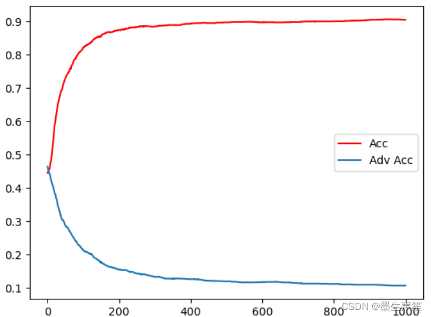

  ```python
  acc_set_cpu = [acc.cpu().detach() for acc in acc_set]
  advacc_set_cpu = [advacc.cpu().detach() for advacc in advacc_set]
  plt1 = plt.plot(np.arange(len(acc_set_cpu)),acc_set_cpu,c = 'r',label = 'Acc')
  plt2 = plt.plot(np.arange(len(advacc_set_cpu)),advacc_set_cpu,label = 'Adv Acc')
  plt.legend()
  plt.show()
  plt.close()
  ```

### **应用推广**

这种对抗方法还可以应用在很多领域。例如，在股市预测的任务中，需要对原始数据中的超额特征和市场特征进行区分，即可使用此方法，尽可能提高模型对两种特征的区分能力。

更多应用场景欢迎补充！